# Practical Machine Learning

Huang,Zhen

2016-7-20

## Getting and Cleaning Data

We use the following code to get the data:(Should download 2 csvs into your work directory first)

```r
train <- read.csv("pml-training.csv")
test <- read.csv("pml-testing.csv")
```

A glimpse at the head of training data tells us that there are lots of columns filled with NAs or Blanks, so we first summarize the number of NAs in each column:

```
## Number of NAs or Blanks in each column:
```

```
##   [1]     0     0     0     0     0     0     0     0     0     0     0
##  [12] 19216 19216 19216 19216 19216 19216 19216 19216 19216 19216 19216
##  [23] 19216 19216 19216 19216 19216 19216 19216 19216 19216 19216 19216
##  [34] 19216 19216 19216     0     0     0     0     0     0     0     0
##  [45]     0     0     0     0     0 19216 19216 19216 19216 19216 19216
##  [56] 19216 19216 19216 19216     0     0     0     0     0     0     0
##  [67]     0     0 19216 19216 19216 19216 19216 19216 19216 19216 19216
##  [78] 19216 19216 19216 19216 19216 19216     0     0     0 19216 19216
##  [89] 19216 19216 19216 19216 19216 19216 19216 19216 19216 19216 19216
## [100] 19216 19216     0 19216 19216 19216 19216 19216 19216 19216 19216
## [111] 19216 19216     0     0     0     0     0     0     0     0     0
## [122]     0     0     0 19216 19216 19216 19216 19216 19216 19216 19216
## [133] 19216 19216 19216 19216 19216 19216 19216     0 19216 19216 19216
## [144] 19216 19216 19216 19216 19216 19216 19216     0     0     0     0
## [155]     0     0     0     0     0     0
```

From these results, we can see that numbers of NAs and Blanks in a column are either a lot or none, so a simple data cleaning method is to remove all columns with NA(We also remove the first column because it is useless in our prediction):

```r
cols <- colSums(is.na(train)) == 0  # Blanks have been converted to NAs
train <- train[, cols]
test <- test[, cols]
train <- train[,-1]
test <- test[,-1]
```

## Variable Analysis

Looking at the summary of our data(Appendix 1), we can find that we have *user_name*, *cvtd_timestamp*, *new_window* and our response *classe* as categorical variables and all others as continuous variables. Thus, a good algorithm to consider is random forest because it carries out feature selection automatically and preprocessing is not needed.

Before our model training, we still need to sketch outliers since outliers can affect our modeling. A boxplot showing the values of our variables are shown below:

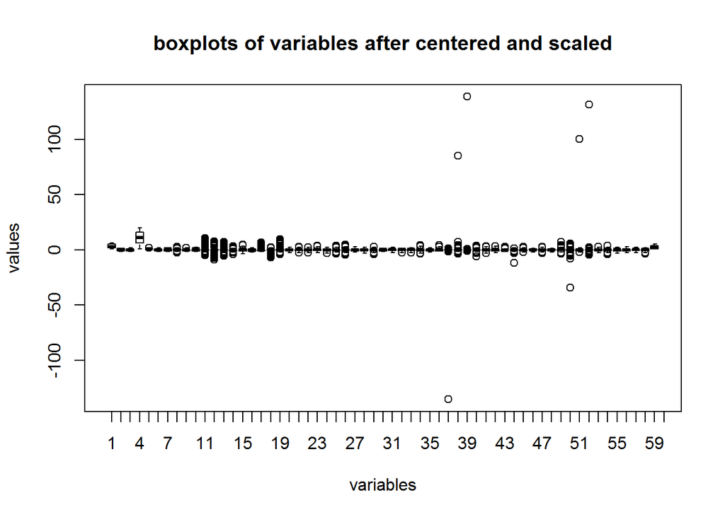

```r
suppressMessages(library(outliers))
absScores <- abs(scores(train[,c(38,39,40,51,52,53)]))
colSums((absScores) > 3) # We regard absScores > 3 as outliers
```

```
## gyros_dumbbell_y gyros_dumbbell_z accel_dumbbell_x  gyros_forearm_y
##              104                1              296                1
##  gyros_forearm_z  accel_forearm_x
##                5                0
```

Since outliers are rare, and random forest requires minimum model assumptions, we can directly carry out the training and validation process on this data(centering and scaling are not needed).

## Model Training and Validation

As discussed before, we train our model using random forests. We trained and validated our model for ten times using different training sets and validation sets. The following code shows how we train our random forest model:

```r
suppressMessages(library(randomForest))
rf <- list()
seed <- 104999 ## a big prime number, for reproducible purpose
for (i in 1:10) { ## we train 10 different models to test the accuracy of rf
  set.seed(seed + i)
  inTrain <- createDataPartition(train$classe, p = 0.8, list = FALSE)
  testing <- train[-inTrain,]
  rf <- randomForest(classe~., data = train, subset = inTrain)
  save(rf, file = paste("rf", toString(i), ".RData", sep = ""))
  prediction <- predict(rf, testing)
  CM <- confusionMatrix(prediction, testing$classe)
  cat(paste("test", i, ":\n", sep = ""))
  print(CM$overall[c("Accuracy", "AccuracyLower", "AccuracyUpper")], sep = "")
}
```

```
## test1:
##      Accuracy AccuracyLower AccuracyUpper
##     0.9992353     0.9977668     0.9998423
## test2:
##      Accuracy AccuracyLower AccuracyUpper
##     0.9994902     0.9981596     0.9999383
## test3:
##      Accuracy AccuracyLower AccuracyUpper
##     0.9992353     0.9977668     0.9998423
## test4:
##      Accuracy AccuracyLower AccuracyUpper
##     0.9997451     0.9985806     0.9999935
## test5:
##      Accuracy AccuracyLower AccuracyUpper
##     0.9984706     0.9966740     0.9994385
## test6:
##      Accuracy AccuracyLower AccuracyUpper
##     0.9994902     0.9981596     0.9999383
## test7:
##      Accuracy AccuracyLower AccuracyUpper
##     0.9992353     0.9977668     0.9998423
## test8:
##      Accuracy AccuracyLower AccuracyUpper
##     0.9992353     0.9977668     0.9998423
## test9:
##      Accuracy AccuracyLower AccuracyUpper
##     0.9997451     0.9985806     0.9999935
## test10:
##      Accuracy AccuracyLower AccuracyUpper
##     0.9984706     0.9966740     0.9994385
```

To see the full results including the confusion matrix and other metrics for our model, Appendix 2 provides a comprehensive summary.

## Conclusion and Prediction

Random forest performs very well on our data, if our dataset is representative, out-of-bag errors will be less than 0.5%. Furthermore, we do not make any assumptions when building our model, so we should expect a good prediction accuracy using model 9 on our test set.

Before we make our prediction, we need to transform our test data into the same format as training data:

```r
for (i in 1:length(names(train))) {
  class(test[,i]) <- class(train[,i])
  if(class(test[,i]) == "factor") {
    levels(test[,i]) <- levels(train[,i])
  }
}
```

Then we use model 9 to predict our test data, and here are the results:

```
##  1  2  3  4  5  6  7  8  9 10 11 12 13 14 15 16 17 18 19 20
##  B  A  B  A  A  E  D  B  A  A  B  C  B  A  E  E  A  B  B  B
## Levels: A B C D E
```

## Appendix

1. Summary of the Variables

```
##     user_name    raw_timestamp_part_1 raw_timestamp_part_2
##  adelmo  :3892   Min.   :1.322e+09    Min.   :   294
##  carlitos:3112   1st Qu.:1.323e+09    1st Qu.:252912
##  charles :3536   Median :1.323e+09    Median :496380
##  eurico  :3070   Mean   :1.323e+09    Mean   :500656
##  jeremy  :3402   3rd Qu.:1.323e+09    3rd Qu.:751891
##  pedro   :2610   Max.   :1.323e+09    Max.   :998801
##
##           cvtd_timestamp  new_window    num_window      roll_belt
##  28/11/2011 14:14: 1498   no :19216   Min.   :  1.0   Min.   :-28.90
##  05/12/2011 11:24: 1497   yes:  406   1st Qu.:222.0   1st Qu.:  1.10
##  30/11/2011 17:11: 1440               Median :424.0   Median :113.00
##  05/12/2011 11:25: 1425               Mean   :430.6   Mean   : 64.41
##  02/12/2011 14:57: 1380               3rd Qu.:644.0   3rd Qu.:123.00
##  02/12/2011 13:34: 1375               Max.   :864.0   Max.   :162.00
##  (Other)         :11007
##    pitch_belt          yaw_belt       total_accel_belt  gyros_belt_x
##  Min.   :-55.8000   Min.   :-180.00   Min.   : 0.00    Min.   :-1.040000
##  1st Qu.:  1.7600   1st Qu.: -88.30   1st Qu.: 3.00    1st Qu.:-0.030000
##  Median :  5.2800   Median : -13.00   Median :17.00    Median : 0.030000
##  Mean   :  0.3053   Mean   : -11.21   Mean   :11.31    Mean   :-0.005592
##  3rd Qu.: 14.9000   3rd Qu.:  12.90   3rd Qu.:18.00    3rd Qu.: 0.110000
##  Max.   : 60.3000   Max.   : 179.00   Max.   :29.00    Max.   : 2.220000
##
##   gyros_belt_y       gyros_belt_z      accel_belt_x       accel_belt_y
##  Min.   :-0.64000   Min.   :-1.4600   Min.   :-120.000   Min.   :-69.00
##  1st Qu.: 0.00000   1st Qu.:-0.2000   1st Qu.: -21.000   1st Qu.:  3.00
##  Median : 0.02000   Median :-0.1000   Median : -15.000   Median : 35.00
##  Mean   : 0.03959   Mean   :-0.1305   Mean   :  -5.595   Mean   : 30.15
##  3rd Qu.: 0.11000   3rd Qu.:-0.0200   3rd Qu.:  -5.000   3rd Qu.: 61.00
##  Max.   : 0.64000   Max.   : 1.6200   Max.   :  85.000   Max.   :164.00
##
##   accel_belt_z     magnet_belt_x   magnet_belt_y   magnet_belt_z
##  Min.   :-275.00   Min.   :-52.0   Min.   :354.0   Min.   :-623.0
##  1st Qu.:-162.00   1st Qu.:  9.0   1st Qu.:581.0   1st Qu.:-375.0
##  Median :-152.00   Median : 35.0   Median :601.0   Median :-320.0
##  Mean   : -72.59   Mean   : 55.6   Mean   :593.7   Mean   :-345.5
##  3rd Qu.:  27.00   3rd Qu.: 59.0   3rd Qu.:610.0   3rd Qu.:-306.0
##  Max.   : 105.00   Max.   :485.0   Max.   :673.0   Max.   : 293.0
##
```

[output cut: 73 more lines]

```
##  Min.   :-446.00   Min.   :-1280.0   Min.   :-896.0   Min.   :-973.0
##  1st Qu.:-182.00   1st Qu.: -616.0   1st Qu.:   2.0   1st Qu.: 191.0
##  Median : -39.00   Median : -378.0   Median : 591.0   Median : 511.0
##  Mean   : -55.29   Mean   : -312.6   Mean   : 380.1   Mean   : 393.6
##  3rd Qu.:  26.00   3rd Qu.:  -73.0   3rd Qu.: 737.0   3rd Qu.: 653.0
##  Max.   : 291.00   Max.   :  672.0   Max.   :1480.0   Max.   :1090.0
##
##  classe
##  A:5580
##  B:3797
##  C:3422
##  D:3216
##  E:3607
##
##
```

2. Summary of validation results:

```
## Confusion Matrix and Statistics
##
##           Reference
## Prediction    A    B    C    D    E
##          A 1116    0    0    0    0
##          B    0  759    1    0    0
##          C    0    0  683    0    0
##          D    0    0    0  642    1
##          E    0    0    0    1  720
##
## Overall Statistics
##
##                Accuracy : 0.9992
##                  95% CI : (0.9978, 0.9998)
##     No Information Rate : 0.2845
##     P-Value [Acc > NIR] : < 2.2e-16
##
##                   Kappa : 0.999
##  Mcnemar's Test P-Value : NA
##
## Statistics by Class:
##
##                      Class: A Class: B Class: C Class: D Class: E
## Sensitivity            1.0000   1.0000   0.9985   0.9984   0.9986
## Specificity            1.0000   0.9997   1.0000   0.9997   0.9997
## Pos Pred Value         1.0000   0.9987   1.0000   0.9984   0.9986
## Neg Pred Value         1.0000   1.0000   0.9997   0.9997   0.9997
## Prevalence             0.2845   0.1935   0.1744   0.1639   0.1838
## Detection Rate         0.2845   0.1935   0.1741   0.1637   0.1835
## Detection Prevalence   0.2845   0.1937   0.1741   0.1639   0.1838
## Balanced Accuracy      1.0000   0.9998   0.9993   0.9991   0.9992
## Confusion Matrix and Statistics
##
##           Reference
## Prediction    A    B    C    D    E
##          A 1115    0    0    0    0
##          B    1  759    1    0    0
##          C    0    0  683    0    0
##          D    0    0    0  643    0
##          E    0    0    0    0  721
```

[output cut: 255 more lines]

```
##
##                   Kappa : 0.9981
##  Mcnemar's Test P-Value : NA
##
## Statistics by Class:
##
##                      Class: A Class: B Class: C Class: D Class: E
## Sensitivity            1.0000   1.0000   0.9956   0.9969   0.9986
## Specificity            1.0000   0.9997   0.9994   0.9991   1.0000
## Pos Pred Value         1.0000   0.9987   0.9971   0.9953   1.0000
## Neg Pred Value         1.0000   1.0000   0.9991   0.9994   0.9997
## Prevalence             0.2845   0.1935   0.1744   0.1639   0.1838
## Detection Rate         0.2845   0.1935   0.1736   0.1634   0.1835
## Detection Prevalence   0.2845   0.1937   0.1741   0.1642   0.1835
## Balanced Accuracy      1.0000   0.9998   0.9975   0.9980   0.9993
```